Lake Name: Eagle Pond

Lake acreage: 40.28814825

County: FRANKLIN

PWLID: 0902-0104

Waterbody Classification: C

Coordinates: 44.668999,-74.273804

Is this waterbody a public water supply: No

Are there DOH desingated beaches on this waterbody: No

Open Water Indicators

2018 Sampling Results

Seasonal Change

Longterm Avg

Season Avg

Season Diff From Avg

05-27

06-10

07-01

07-29

08-11

08-25

09-15

07-15

Clarity (m)

1.40

1.40

1.50

1.50

1.50

1.60

1.70

1.50

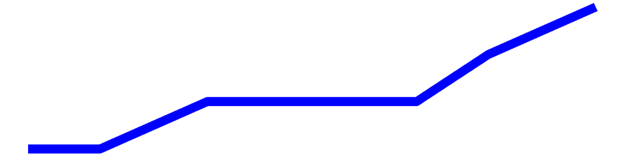

1.45669231

1.5125000

Surface TP (mg/L)

0.01

0.01

0.02

0.01

0.01

0.01

0.01

0.01

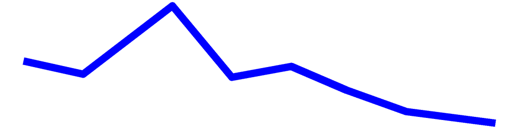

0.01938784

0.0121250

Surface TDP (mg/L)

0.01

0.00

0.01

0.00

0.00

0.00

0.00

0.01

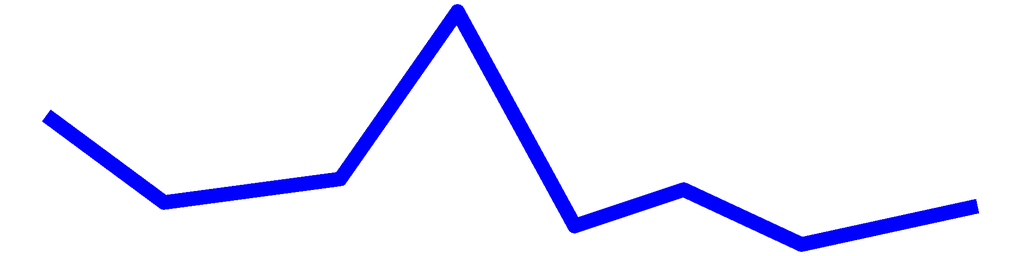

0.0057875

Deep TP (mg/L)

0.00805000

Deep TDP (mg/L)

TN (mg/L)

0.57

0.46

0.54

0.48

0.51

0.42

0.45

0.70

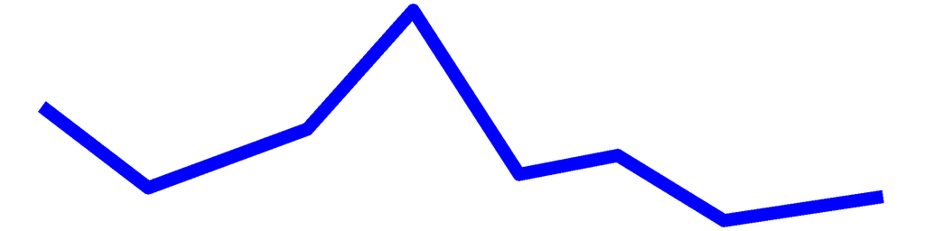

0.42275345

0.5173750

TDN (mg/L)

0.55

0.47

0.51

0.34

0.48

0.45

0.40

0.64

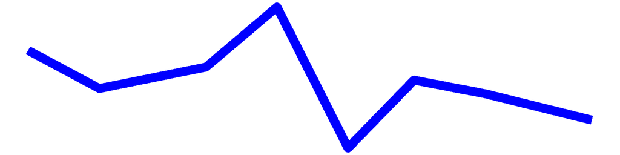

0.28128571

0.4803750

TN:TP

40.66

37.31

25.46

35.90

49.19

55.82

75.22

58.58

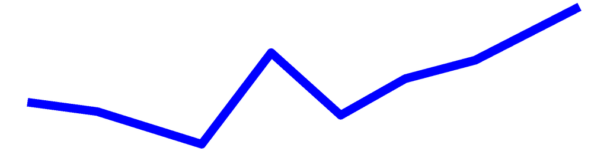

47.2687080

Surface NH3 (mg/L)

0.05

0.03

0.11

0.03

0.08

0.04

0.06

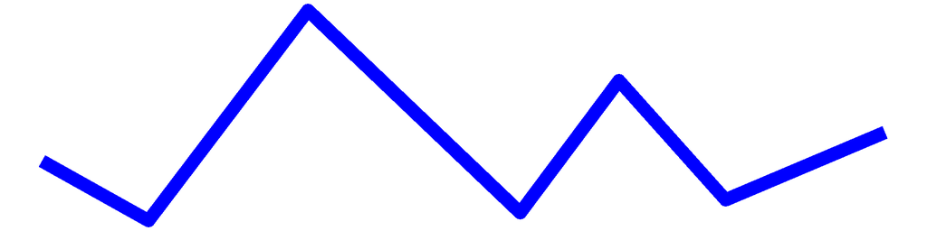

0.05119487

0.0590000

Deep NH3 (mg/L)

Chl.a (ug/L)

3.10

1.90

1.60

2.90

1.30

2.00

0.70

6.40

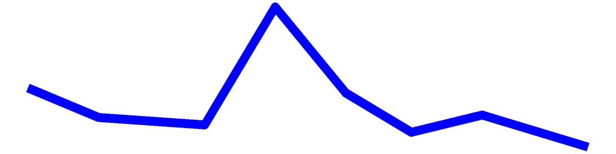

2.55470000

2.4875000

pH

8.42

7.05

7.37

7.42

7.34

6.71

7.59

7.87

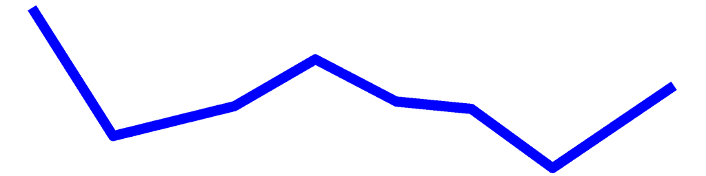

7.86000000

7.4712500

Cond (umho/cm)

162.60

207.10

216.60

230.80

245.00

247.30

224.00

241.00

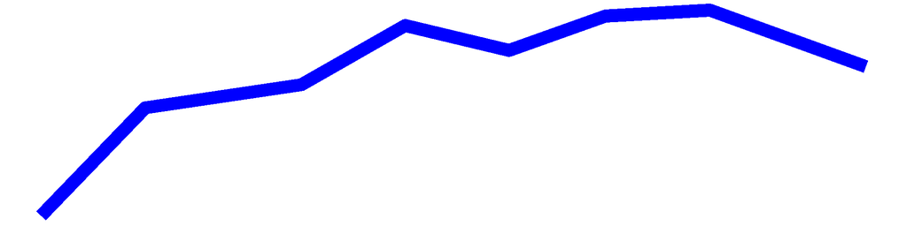

194.47000000

221.8000000

Surface Calcium (mg/L)

14.20538462

Bottom Calcium (mg/L)

Surface Chloride (mg/L)

29.30

34.00

33.49000000

31.6500000

Bottom Chloride (mg/L)

Upper Temp (degC)

19.00

17.00

25.00

20.50

21.00

20.00

19.50

24.00

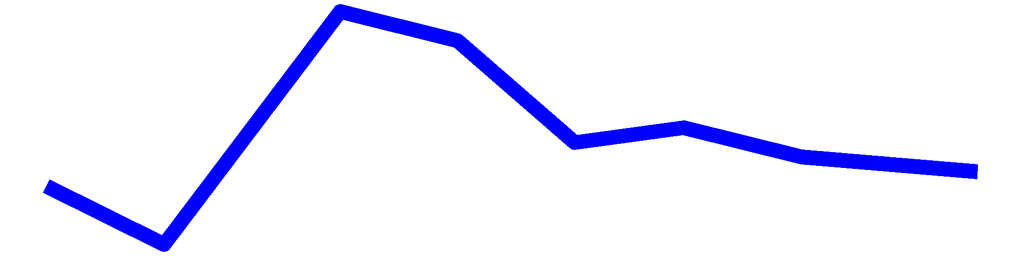

19.21311475

20.7500000

Deep Temp (degC)

FP BG Chl.a (ug/L)

3.01

2.85

5.73

5.61

2.36

0.82

2.16

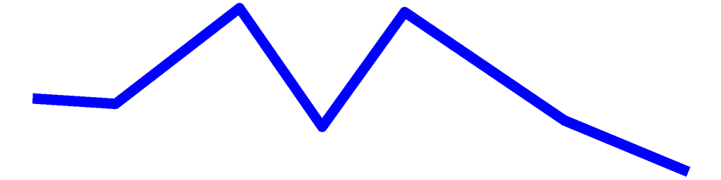

3.2217143

## Eagle Pond – Sampling Season Results

### HABs Status

#### Open Water Algae

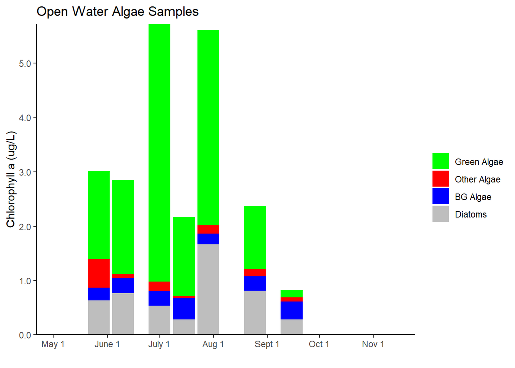

#### Shoreline Algae

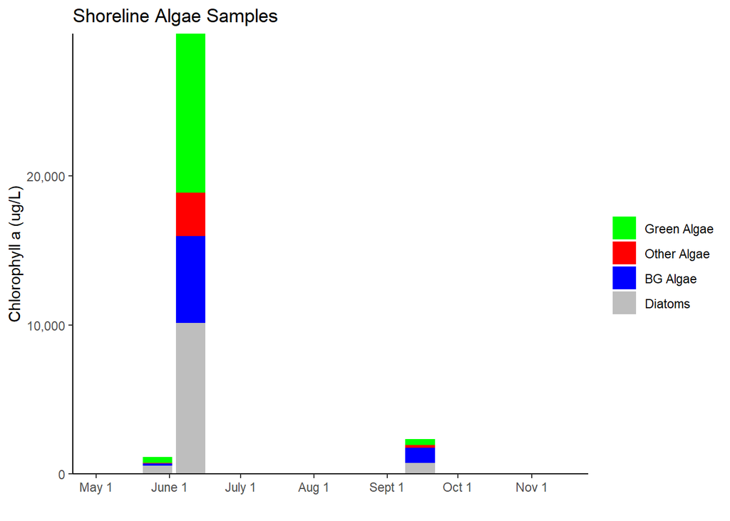

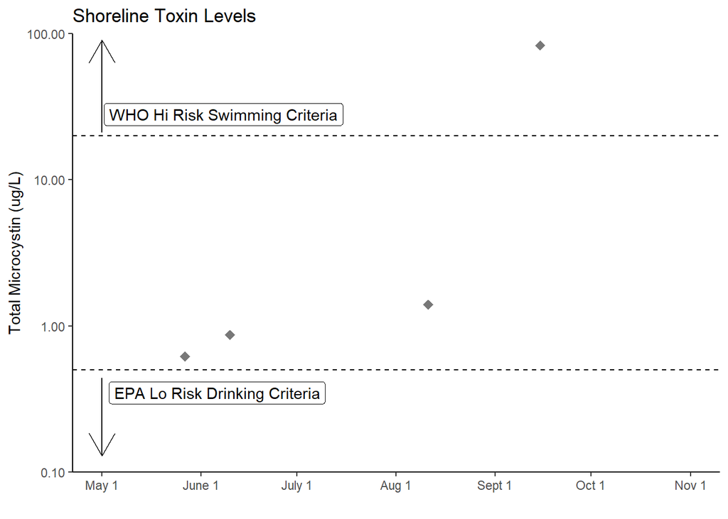

## Eagle Pond Long-Term Trend Analysis

#### Clarity

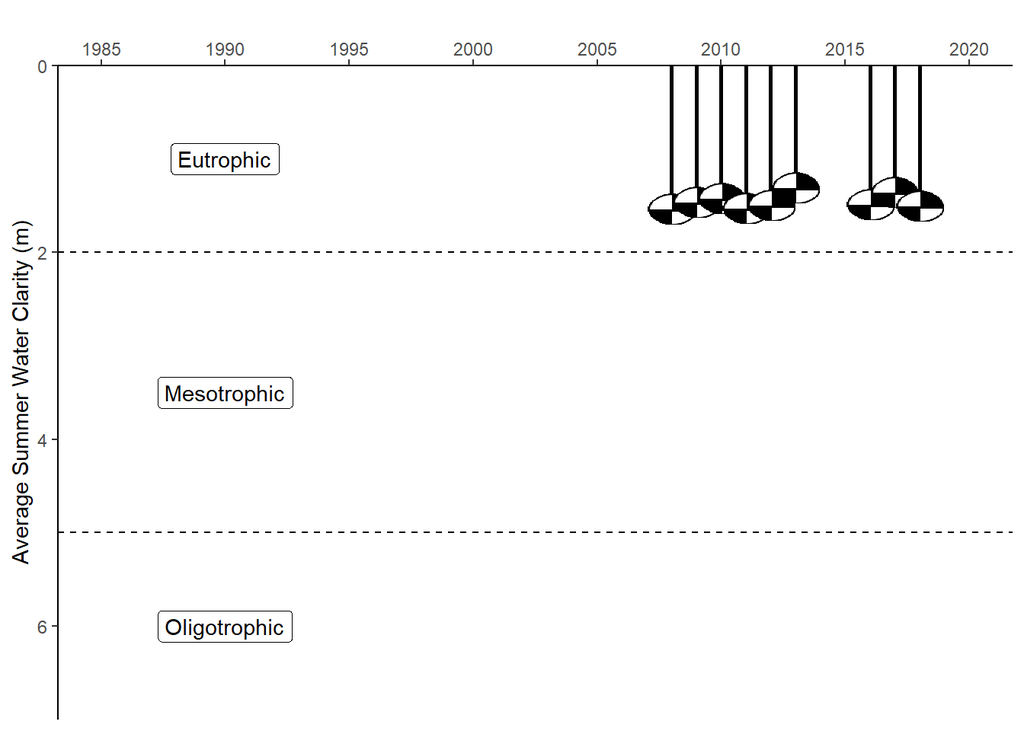

#### Chlorophyll *a*

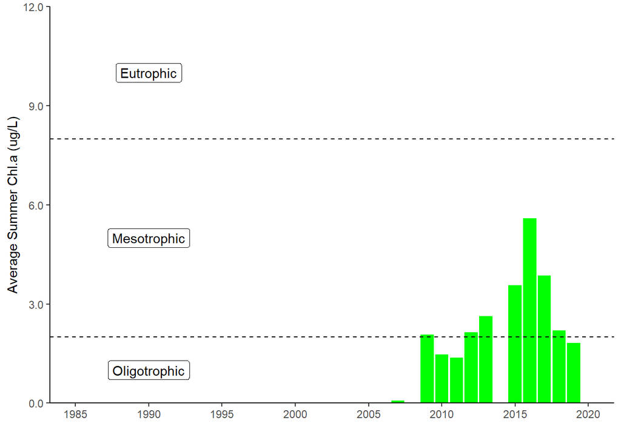

#### Surface and Deep Phosphorus

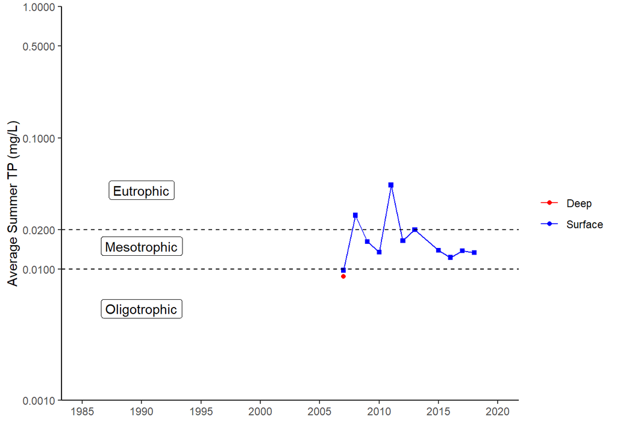

#### Nitrogen

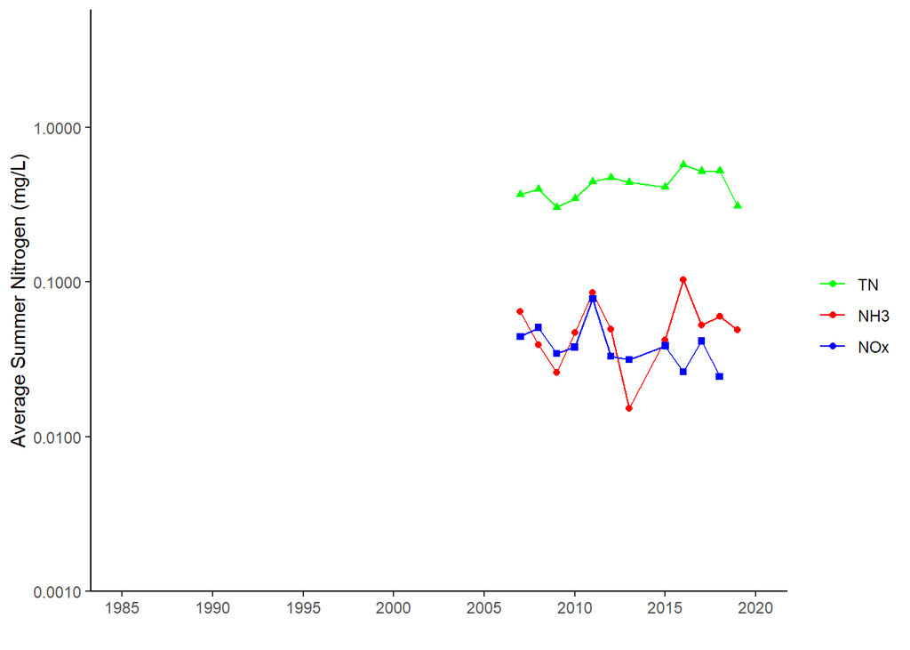

#### TN : TP

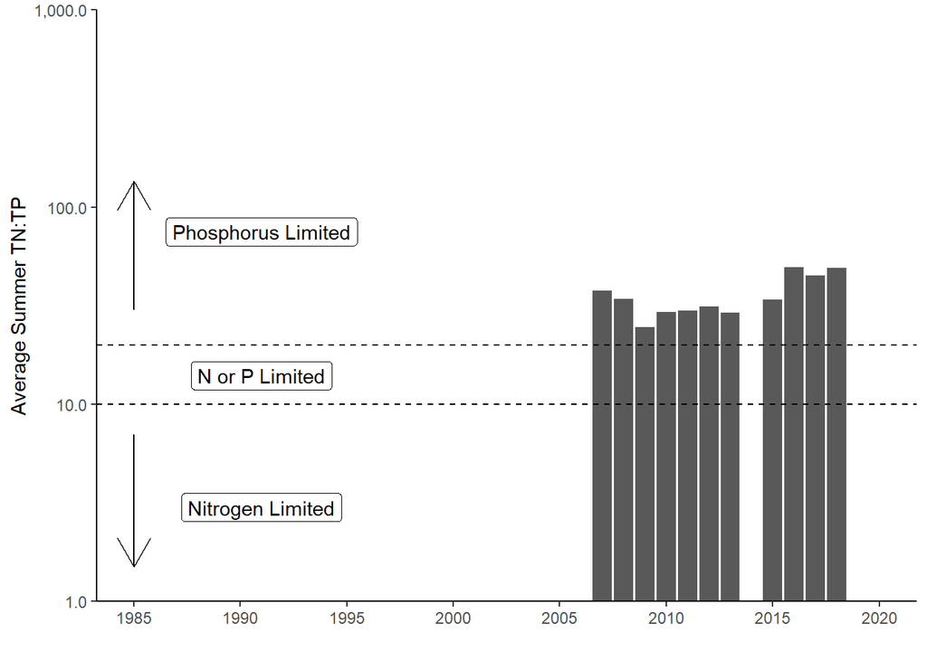

#### pH

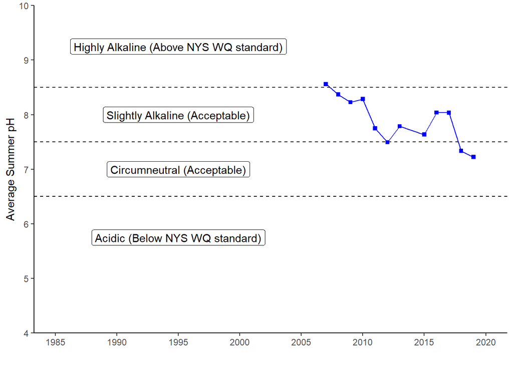

#### Specific Conductance

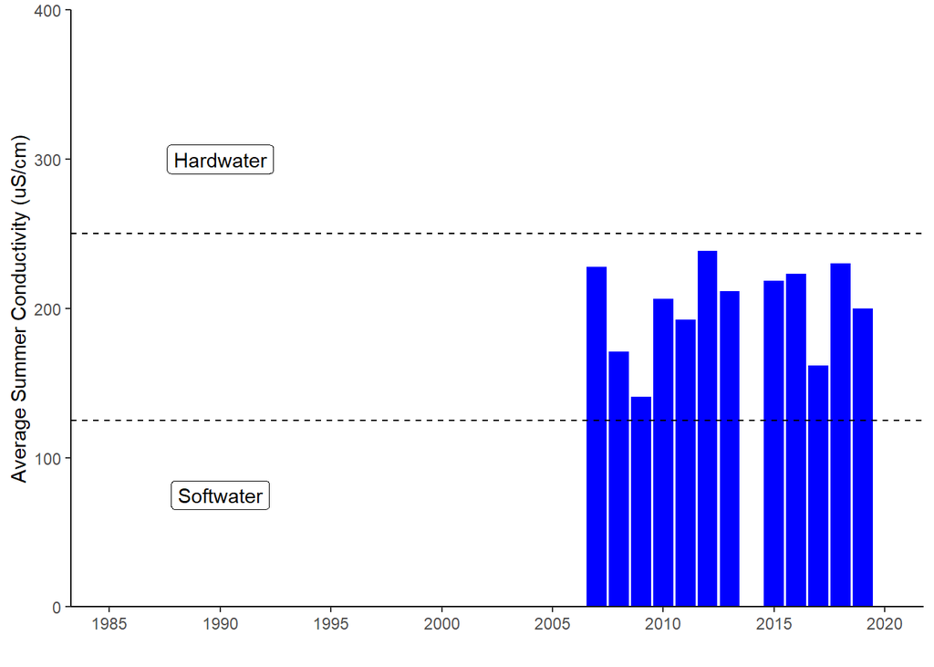

#### Calcium

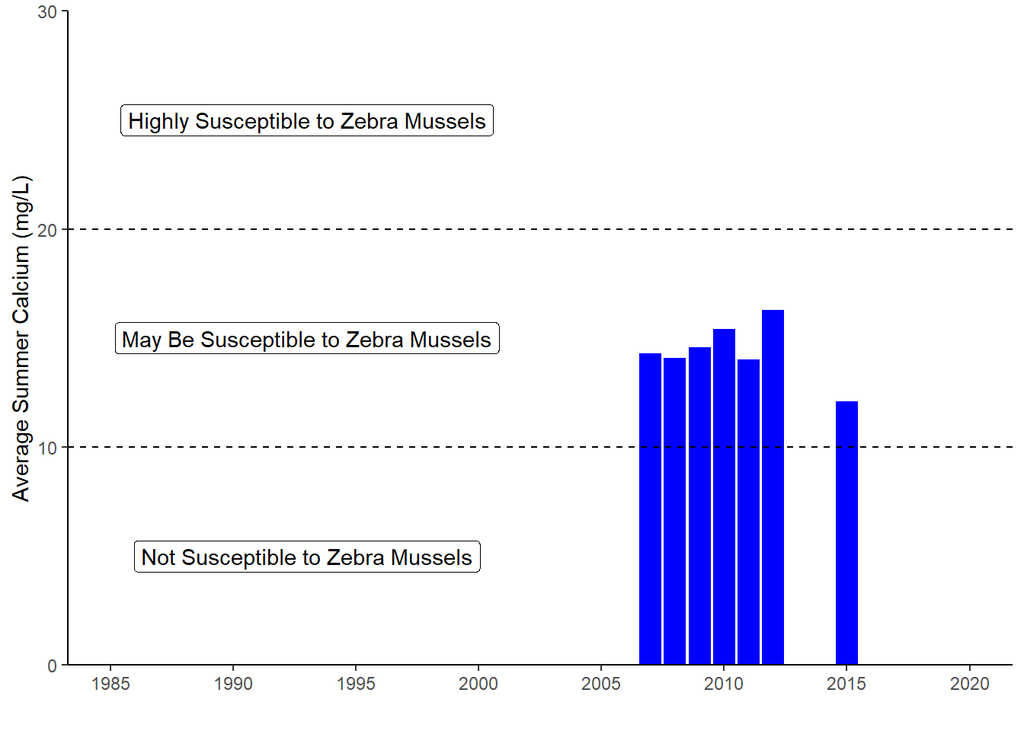

#### Chloride

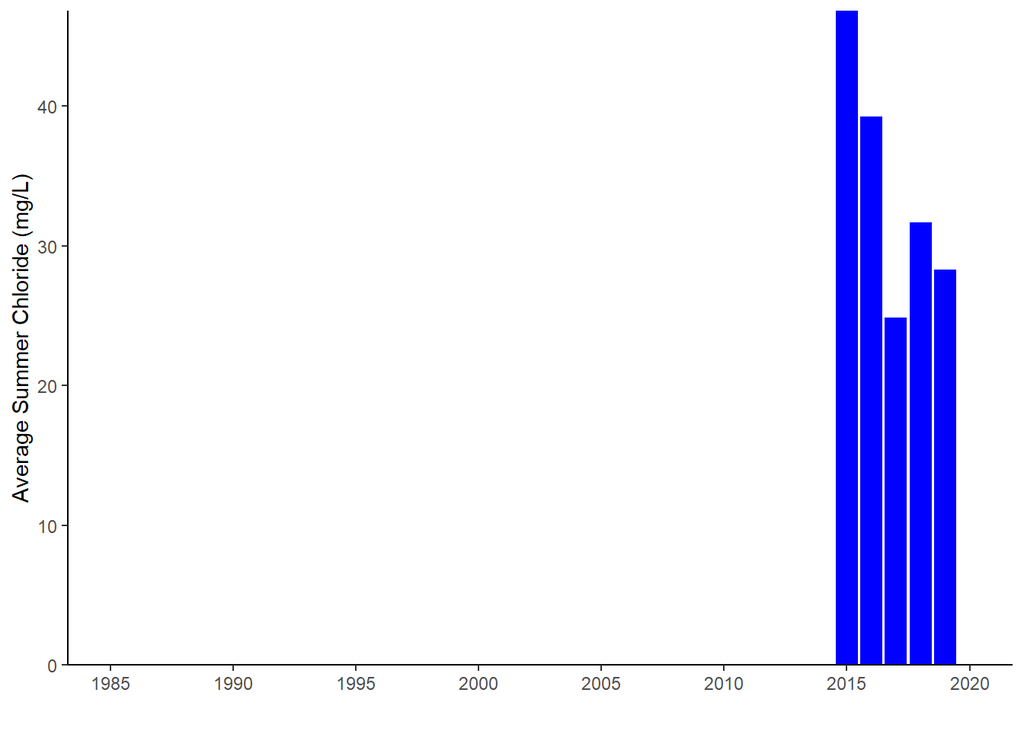

#### Color

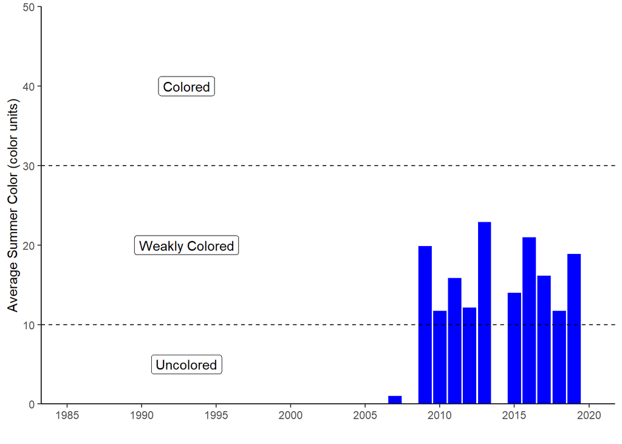

#### Surface and Deep Temperature

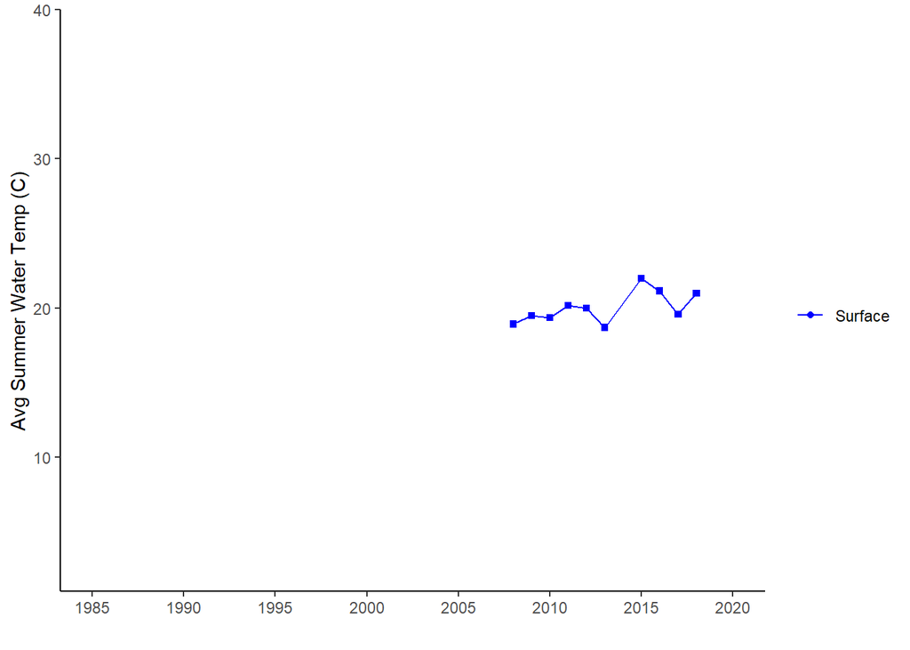

#### Lake Perception

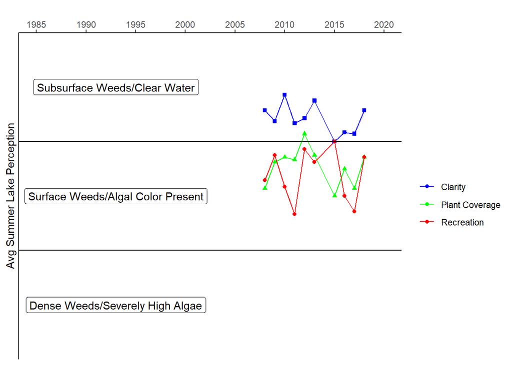

## Eagle Pond - In-Season Analysis

#### In Season Water Clarity

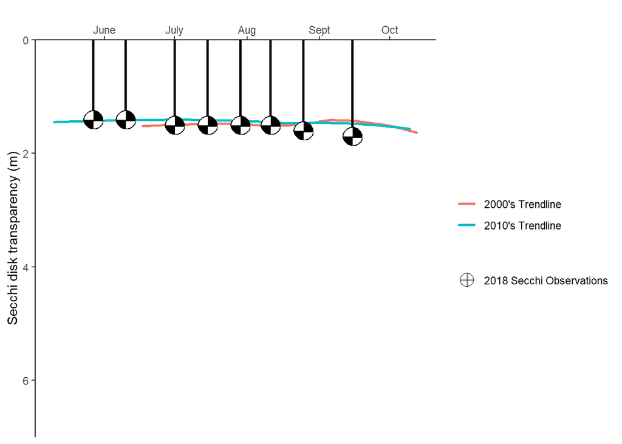

#### In Season Water Temperature

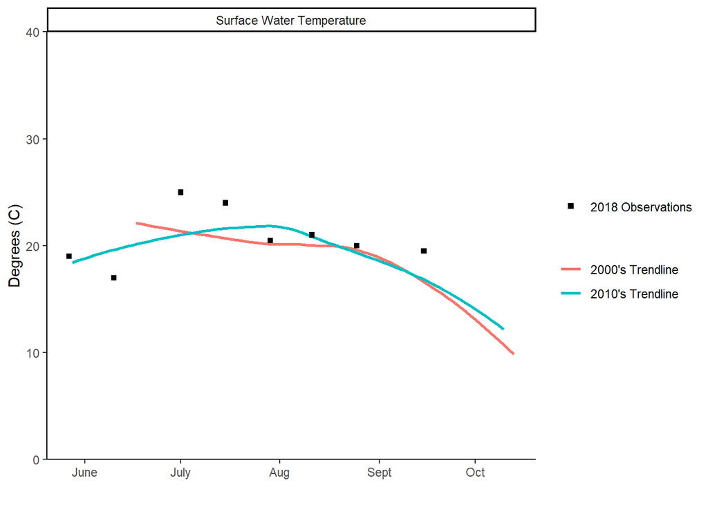